# Qualitative explanatory variables

# Regression with a qualitative and a quantitative explanatory variable

The *trees* data do not have any qualitative explanatory variables, so we will construct one for illustrative purposes. We will replace the variable *Height* by a new variable *Tall* which indicates whether or not the cherry tree is taller than a certain threshold (the sample median height of 76 ft).  
In R, for this purpose we use the *cut* function:

```r
trees$Tall <- cut(trees$Height, breaks = c(-Inf, 76, Inf),
                  labels = c("no", "yes"))
trees$Tall[1:5]
```

```
[1] no  no  no  no  yes
Levels: no yes
```

```r
class(trees$Tall)
```

```
[1] "factor"
```

We perform MLR as we normally would:

[output not shown]

(Note: R defines Tallyes automatically without input from the user)

We conclude that the mean response differs for trees with *Tall = yes* and trees with *Tall = no*.

## Plot of the regression lines

We can see a plot of the two regression lines:

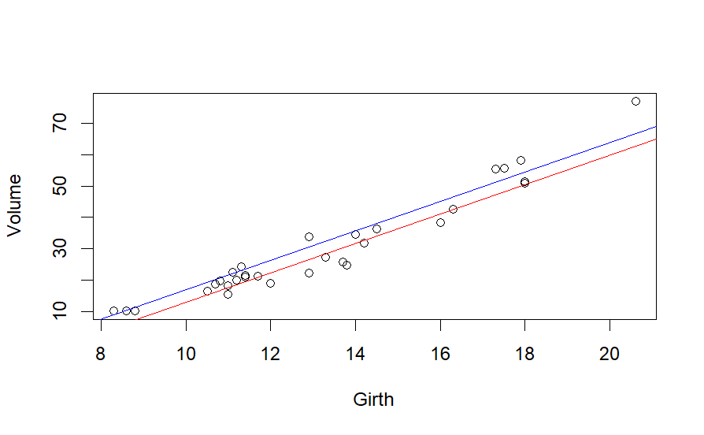